# Untitled

Trox

January 10, 2015

# Introduction to Statistical Learning Datasets

Let’s take a look at the datasets for *An Introduction to Statistical Learning*. The datasets all live as binary data in the ‘ILSR’ package on CRAN, so we can obtain them by running `install.packages('ISLR')`.

For our EDA, we will first load `magrittr`, `dplyr`, and `ggplot2`:

```r
library(magrittr)
library(dplyr)
library(ggplot2)
```

## Wage

The `Wage` dataset covers wages and various socioeconomic variables for working men. We wrap the dataset up in a `dplyr::tbl` to get nicer printing

```r
full_wages = tbl_df(ISLR::Wage)
dim(full_wages)
```

```
## [1] 3000   12
```

```r
colnames(full_wages)
```

```
##  [1] "year"       "age"        "sex"        "maritl"     "race"
##  [6] "education"  "region"     "jobclass"   "health"     "health_ins"
## [11] "logwage"    "wage"
```

There are a variety of interesting variables, but for the purposes of ISLR, we focus on `wage` as the response variable and `age`, `year`, and `education` as variables:

```r
wages = full_wages %>% select(wage, education, year, age)
```

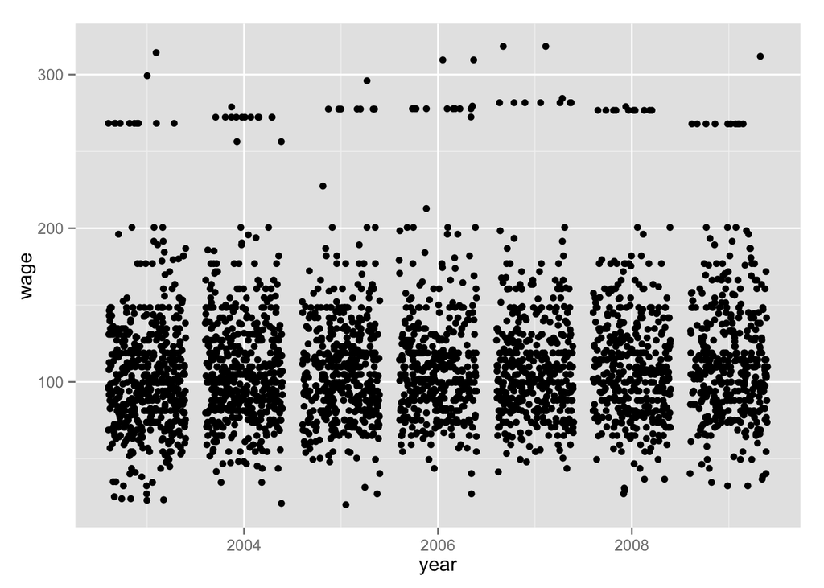

```r
ggplot(wages) + aes(x = year, y = wage) + geom_jitter()
```

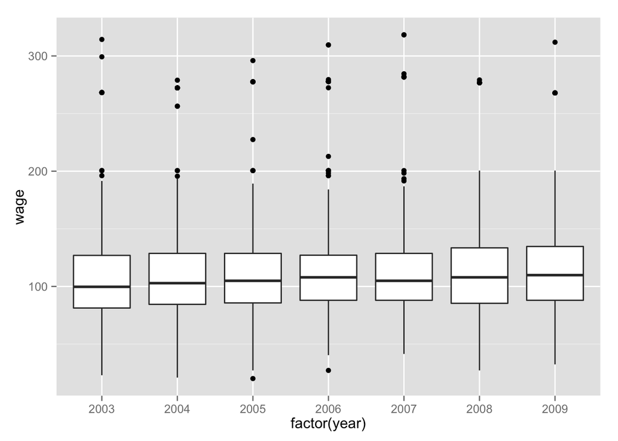

```r
ggplot(wages) + aes(factor(year), wage) + geom_boxplot()
```

Next, let’s look at `age`:

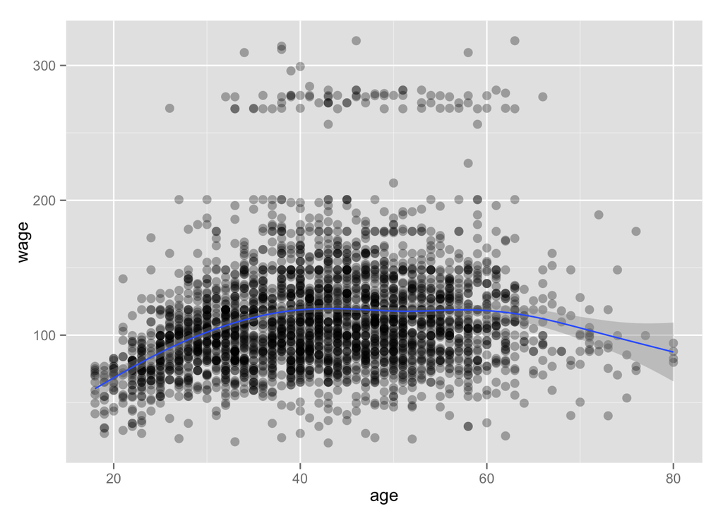

```r
ggplot(wages) + aes(age, wage) + geom_point(alpha=0.3, size=3) + stat_smooth()
```

Now let’s take a look at `education`, and add a splash of color:

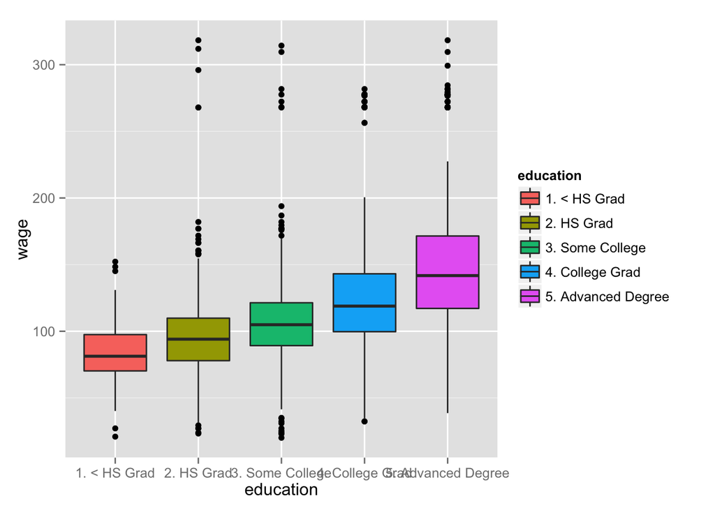

```r
ggplot(wages) + aes(education, wage) + geom_boxplot(aes(fill = education))
```

Finally, let’s use a lattice-type facet plot to look at age and education together:

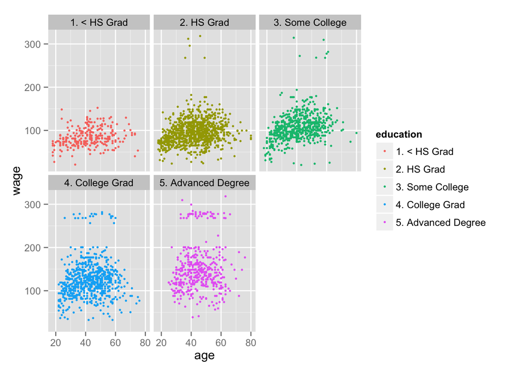

```r
ggplot(wages) + aes(age, wage) + geom_point(size=1, aes(color=education)) + facet_wrap(~ education)
```

## Stock Market

The stock market data gives today’s market movement, along with a measure of trading volume and several normalized lags in market movement. In the context of ISLR, this dataset is typically used for classification of whether today’s market rose or fell (although in finance, the amount it moved is usually much more important)

```r
smkt = tbl_df(ISLR::Smarket)
smkt
```

```
## Source: local data frame [1,250 x 9]
##
##    Year   Lag1   Lag2   Lag3   Lag4   Lag5 Volume  Today Direction
## 1  2001  0.381 -0.192 -2.624 -1.055  5.010 1.1913  0.959        Up
## 2  2001  0.959  0.381 -0.192 -2.624 -1.055 1.2965  1.032        Up
## 3  2001  1.032  0.959  0.381 -0.192 -2.624 1.4112 -0.623      Down
## 4  2001 -0.623  1.032  0.959  0.381 -0.192 1.2760  0.614        Up
## 5  2001  0.614 -0.623  1.032  0.959  0.381 1.2057  0.213        Up
## 6  2001  0.213  0.614 -0.623  1.032  0.959 1.3491  1.392        Up
## 7  2001  1.392  0.213  0.614 -0.623  1.032 1.4450 -0.403      Down
## 8  2001 -0.403  1.392  0.213  0.614 -0.623 1.4078  0.027        Up
## 9  2001  0.027 -0.403  1.392  0.213  0.614 1.1640  1.303        Up
## 10 2001  1.303  0.027 -0.403  1.392  0.213 1.2326  0.287        Up
## ..  ...    ...    ...    ...    ...    ...    ...    ...       ...
```

This data is not easy to visualize; in the intro chapter to ISLR, they show boxplots of each lag given the sign of today’s movement. These plots don’t show much, so we plot them only for the first lag:

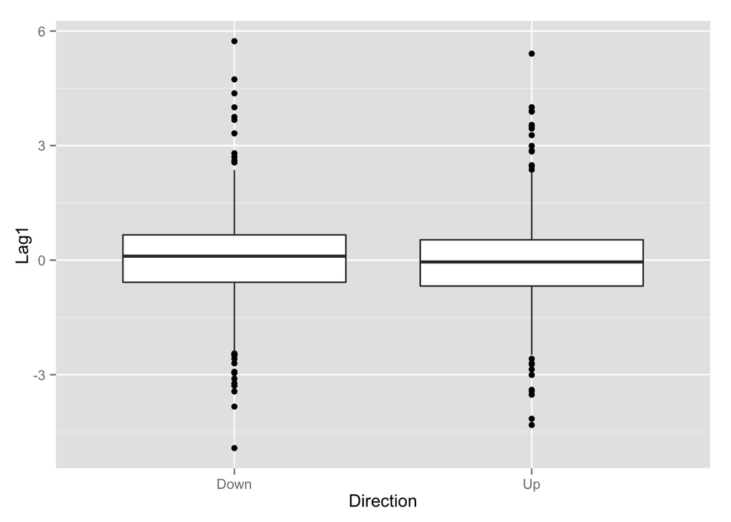

```r
ggplot(smkt) + aes(Direction, Lag1) + geom_boxplot()
```

## Gene Expression

The NCI60 gene expression dataset has a matrix with 64 observations of 6830 gene expression measurements on cancer patients. This matrix is found in the `$data` entry of the list, while the `$labs` entry is a length-64 character vector with the type of cancer.

```r
nci60 = ISLR::NCI60
class(nci60)
```

```
## [1] "list"
```

```r
names(nci60)
```

```
## [1] "data" "labs"
```

```r
class(nci60$data)
```

```
## [1] "matrix"
```

```r
dim(nci60$data)
```

```
## [1]   64 6830
```

```r
nci60$labels
```

[output not shown]

Although this is a labeled dataset which we might use for classification, for the purposes of ISLR we will use it to demonstrate dimensionality reduction and clustering methods. It’s an interesting dataset with which to cluster, since the known cancer type labels give us a way to judge how well a clustering method is working in practice.

We will plot the first two principle components to get a glimpse at this data. Since we haven’t dug into `R`s machine learning libraries yet, we’ll perform the PCA by hand. The first step is to normalized our data (after plotting the data it looks like this may have already been done, but we do it anyway since this document is partly a warmup to R)

```r
colMus = colMeans(nci60$data)
colSds = apply(nci60$data, 2, sd)
normalized = (nci60$data - colMus) / colSds
```

Note that R broadcasts the vector-matrix operations automatically, as long as only one dimension matches. I’m still not sure how you explicitly broadcast when the matrix is square.

Next, we perform a signular value decomposition

```r
duv = svd(normalized)
```

This factors our data into $X = U D V^T,$ where $V$ is 6830 by 64, and $U$ and $D$ are 64 by 64. Here the columns of $V$ and $U$ are unit vectors and orthogonal. We can think of this factorization as splitting up the linear transformation given by $X$ into a change of basis, encoded by $V$, a diagonal scaling, and another change of basis given by $U.$

Ideally, when we perform PCA we see a steep dropoff in the diagonal, indicating that just a few principle components represent most of the variation in our data. Infortunately, this isn’t the case:

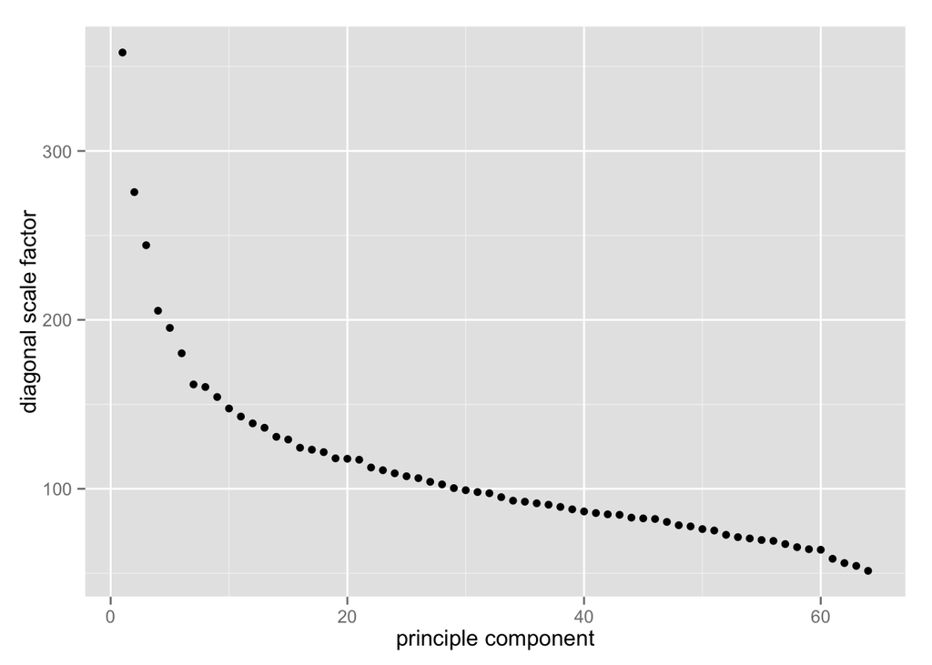

```r
qplot(1:length(duv$d), duv$d,
      xlab = "principle component", ylab = "diagonal scale factor")
```

Nonetheless, we can continue to visualize If we aren’t too concerned about the relative scaling, the columns of $U$ represent our size-64 dataset in each principle component. So to plot the data in the space spanned by the first two principle components, we can run

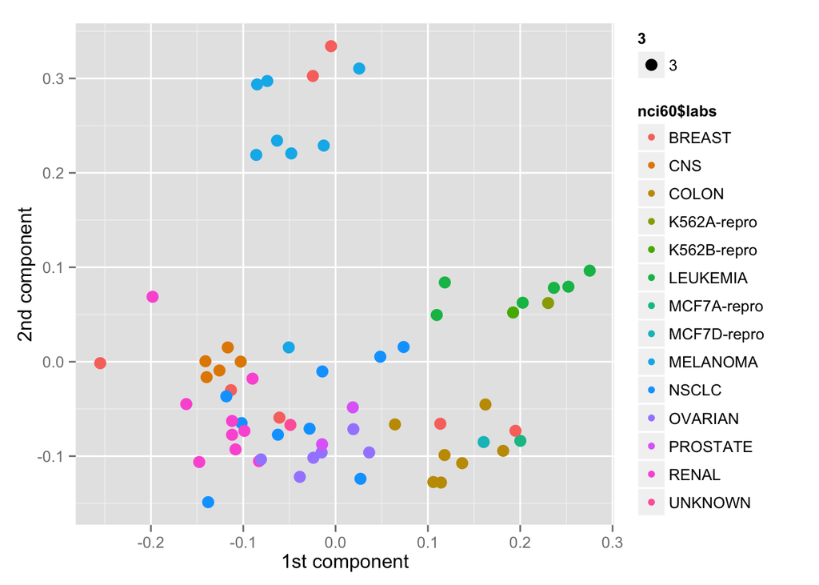

```r
qplot(duv$u[,1], duv$u[,2], size=3,
      xlab = "1st component", ylab = "2nd component",
      color=nci60$labs)
```

(The 3 in the legend happens because qplot assumes we are giving it a data-based value for `size`; I’m not sure how to suppress it, I’m just gettin back into R at this point.) This plot doesn’t quite match the book, probably because the PCA implementation they use differs slightly from ours, or they may have chosen a different normalization method.

## Other datasets

There are quite a few more datasets in ISLR, which you can find by typing `help(package="ISLR")` in the R console in Rstudio (or by finding the package reference on the internet). But the three datasets discussed above are the only three described in Chapter 1, so we will end here for now.